# SOK-2303 - Den nordiske modellen

Mikko Moilanen

## Vi har det bra

### World happiness Index 2024

```
          country happiness_score
1         Finland           7.741
2         Denmark           7.583
3         Iceland           7.525
4          Sweden           7.344
5          Israel           7.341
6     Netherlands           7.319
7          Norway           7.302
8      Luxembourg           7.122
9     Switzerland           7.060
10      Australia           7.057
11    New Zealand           7.029
12     Costa Rica           6.955
13         Kuwait           6.951
14        Austria           6.905
15         Canada           6.900
16        Belgium           6.894
17        Ireland           6.838
18        Czechia           6.822
19      Lithuania           6.818
20 United Kingdom           6.749
```

## Vi har høy levestandard

[interactive chart not shown]

## Vi er like, og vi er rike

[interactive chart not shown]

## Vi er frie

[interactive chart not shown]

## Den nordiske modellen

- Hvorfor er Norge blant landene med høyest velferd; gladest og friest befolkning, høyest levestandard og minst forskjeller mellom folk?
- Og hvorfor er det slik at Norge har vært blant de flinkeste til å absorbere økonomiske sjokk og andre eksternt påførte kriser?
- Mye av forklaringen på suksesshistorien ligger i hvordan vi har organisert den norske samfunnsmodellen

[figure not shown]

## Men…

#### **Innføringskurs i mikroøkonomi**

- Inngrep på markedet fører til redusert velferd
- Konklusjon:
  - Det er best å la markedene være i fred.
  - Unngå alle inngrep på markedene.

#### **Den nordiske modellen**

- Veldig mange og veldig store inngrep på markedene
  - spesielt på arbeidsmarkedet, utdanningsmarkedet, helsemarkedet og forsikringsmarkedet

#### Hvorfor?

#### Hvilke insentiver?

## Den nordiske modellen

## Samfunnets målsettinger

- Mål
  - personlig frihet
    - muligheten til å kunne utvikle egne potensialer på egne premisser
    - økonomisk trygghet er en helt nødvendig betingelse for frihet
  - økonomisk vekst
    - å skape verdier
    - effektivitet: større kake
      - at de fleste er i jobb
      - sløsing og gammeldagse metoder betyr mindre velferd og lønn
  - sosial likhet
    - inntektsutjevning
    - rettferdighet: hvordan fordele kake

## Den nordiske modellens tre grunnpilarer

- økonomisk styring
  - aktiv, stabilitetsorientert økonomisk politikk
  - frihandel
  - lover, skatter og avgifter
  - høy yrkesdeltakelse
- offentlig velferd
  - ordninger som dekkes av et høyt skattenivå
  - universelle ordninger for inntekts- og standardsikring
    - legger til rette for høy yrkesdeltaking og mobilitet
  - skattefinansierte helse- og velferdstjenester og gratis utdanning
    - bidrar til likestilling og utjevning av levekår, helse og yrkesmuligheter
- organisert arbeidsliv
  - sentralisert koordinering av lønnsdannelsen
  - sikrer at norske bedrifter kan konkurrere internasjonalt
  - fører til små lønnsforskjeller og reduserer inntektsulikheter
  - skaper et forutsigbart og stabilt arbeidsliv med høy organisasjonsgrad
  - bidrar til høy sysselsetting og god økonomisk utviklin

## Den nordiske modellens oppslutning

- Verdier
  - tillit
  - solidaritet
  - menneskerettigheter
  - demokrati

## Tillit

- tillit er en forutsetning for oppslutning om velferd
- dyre kollektive ordninger krever tillit og solidaritet
  - velferdsstaten er avhengig av at hver enkelt har en tillit til at «alle de andre» også vil legge pengene sine i den felles potten
- en velfungerende velferdsstat bidrar til å skape tillit
  - blitt holdt ved like av institusjonene velferdsstaten representerer
  - denne gjensidig forsterkende dynamikken er ikke gitt en gang for alle

## Tillit

[interactive chart not shown]

## Solidaritet

- oppslutningen om velferdsordningene bygger på et ønske om at inntekt og sosial bakgrunn ikke skal være avgjørende for tilgang til velferdsordninger som utdanning og helsetjenester
- modellen baserer seg på et sterkt krav til solidaritet mellom generasjoner
- mange nordiske innbyggere har en preferanse for likhet

## Demokrati

- gir borgerne muligheten til å delta i beslutningsprosesser
- skaper et samfunn hvor alle har mulighet til å si sin mening og bidra til utformingen av politikk
  - styrker følelsen av eierskap og tilknytning til samfunnet
- krever åpenhet og ansvarlighet fra myndighetenes side
  - kan bidra til å redusere korrupsjon og sikre at offentlige midler brukes på en effektiv og rettferdig måte

## Menneskerettigheter

- fungerer som et grunnlag for mange av de prinsippene og verdiene som kjennetegner modellen
  - respekt for individet:
    - menneskerettighetene anerkjenner den iboende verdigheten og likheten til alle individer
- styrking av sosial samhørighet og tillit: ved å fremme og beskytte menneskerettighetene, bygger de nordiske landene et samfunn hvor alle borgere har mulighet til å delta fullt ut
- likestilling og mangfold: Menneskerettighetene fremmer likestilling mellom kjønnene og beskyttelse av minoriteters rettigheter. Dette er i tråd med den nordiske modellens fokus på inkludering og mangfold.

## Den nordiske modellens utfordringer

- økt global konkurranse
- klimaproblemer
- migrasjon og europeisk integrasjon
- indre endringer setter modellenes bærekraft og fornyelsesevne på prøve.
  - økende, eldre og mer mangfoldig befolkning
  - urbanisering
  - stigende forventninger til helse, utdanning og velferd

## Eldre befolkning

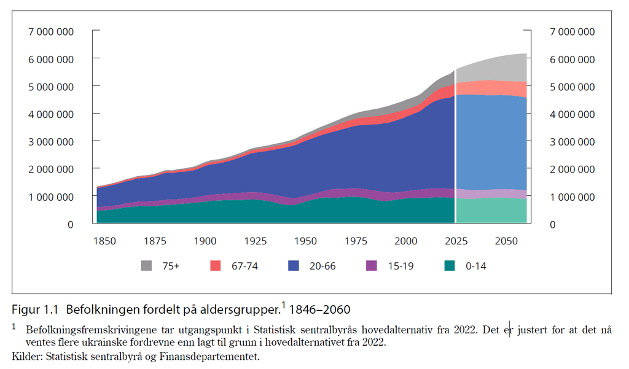

## Fallende inntekter fra olje og gass

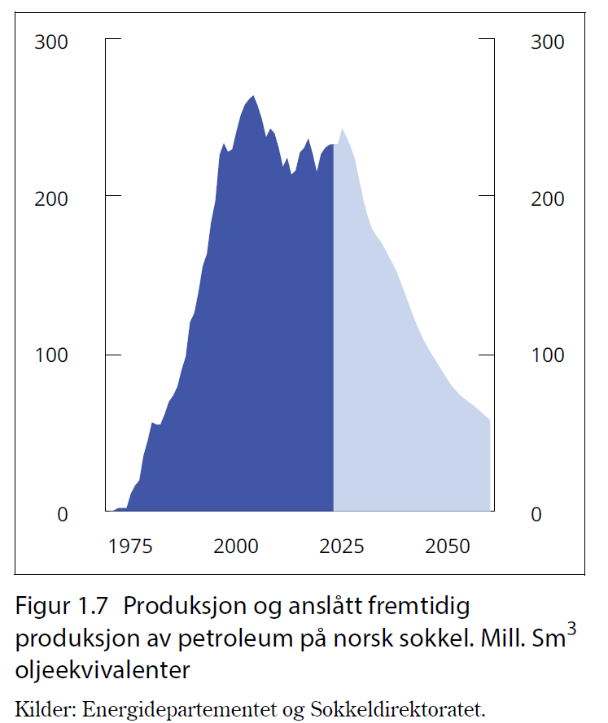

## Hvorfor er yrkesdeltakelse viktig

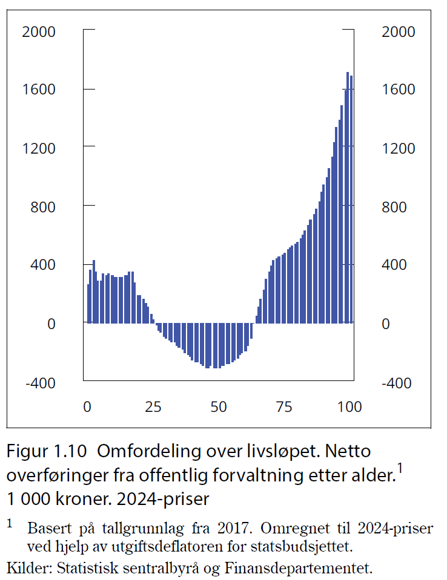

## Den nordiske modellens utfordringer

- **Et kjernespørsmål er om man klarer å fornye institusjonene og virkemidlene uten at det går på bekostning av målsettinger om rettferdig fordeling, balansert vekst, høy yrkesdeltakelse og den politiske oppslutningen om modellen**

## Den nordiske modellen

## Læringsmål: Kunnskaper og forståelse

- **Studentene skal ha innsikt i sentrale trekk ved den nordiske samfunnsmodellen**
- **Studentene skal forstå offentlige inngrep i økonomien og ha innblikk i velferdsøkonomiske problemstillinger**
  - **skal forstå teoretiske argumenter bak velferdsordningenes innretning og omfang**
  - **skal forstå insentivproblemer som oppstår i skjæringspunktet mellom velferdsstat og marked**
    - Bakgrunnen til, og ulike politiske og moralfilosofiske begrunnelser for, velferdsstaten
    - Hvordan effektivitet, rettferdighet og insentivproblemer påvirker arbeidsmarkedet og ulike velferdspolitiske ordninger
    - Hvordan ulikhet defineres og operasjonaliseres i normative analyser
    - Beskatningens samfunnsøkonomiske kostnader og begrensninger
    - Hvordan arbeidsmarkedet fungerer, blant annet trekantssamarbeidets rolle i lønnsdannelsen, og hvordan familie-, innvandrings- og likestillingspolitikken påvirker sysselsetting og verdiskaping
    - Teoretiske argumenter bak viktige overføringsordninger i folketrygden og disinsentiveffekter knyttet til disse
    - Offentlig sektor sin rolle i utdannelses- og helsesektoren

## Læringsmål: Ferdigheter

- Kunne inkorporere politiske og moralfilosofiske teorier i analyse av velferdsstaten
- Kunne analysere
  - hvordan en effektiv allokering av ressursene kan oppnåes i imperfekte markeder
  - fattigdom, ulikhet og velferd
  - Analysere ulike overføringsordninger opp mot effektivitet, fordeling og insentiveffekter
- Kunne analysere og drøfte relasjonen mellom forsikringsmarkeder og sosialforsikringssystem
- Kunne anvende offentlig tilgjengelig statistikk for å analysere aktuelle problemstillinger innen faget

## Læringsmål: Kompetanse

- Ha innsikt om relevante problemstillinger relatert til velferdsstaten
- Kunne planlegge og gjennomføre arbeidsoppgaver og benytte både økonomisk teori og empiriske data for å analysere problemstillinger knyttet til velferdsstaten i tråd med etiske krav og retningslinjer.
- Kunne formidle sentrale teorier, problemstillinger og løsninger i grafisk, analytisk og muntlig form.
- Være i stand til å delta i samfunnsdebatten om velferdspolitikkens ulike virkemidler og deres bærekraft.